# Psychoactive Plants

## Mind Altering Plants Rooted in Human Society

[figure not shown]

[figure not shown]

- **Use of psychoactive plants dates to earliest societies**
  - mix of medicine & spirituality
  - 6,000 years ago, Opium = ‘joy plant’
- **Hieroglyphs show prominent use in Ancient Egypt**
  - belief that certain plants have spiritual properties
  - ashwagandha, lotus, reed, acacia, henbane, opium
- **‘Spirit Molecule’ in indigenous tribes of the Amazon**
  - Ayahuasca vine and Chacruna shrub
- **DMT from *Acacia* used in many cultures**
  - molecule ‘DMT’ powerful hallucinogen
  - ‘Golden Wattle’ is botanical emblem of Australia

## Psychoactive Drugs

- **Affect nervous system by influencing neurotransmitters**
  - or mimicking them
  - neurons → transmitters → receptor
  - inhibitory or excitatory
- **Psychoactives can be stimulants, hallucinogens or depressants**
  - narrow line between medicinal, psychoactive & toxic
- **Stimulants = excite and enhance mental alertness**
- **Hallucinogens = change perception**
- **Depressants = dull mental awareness & induce sleep**

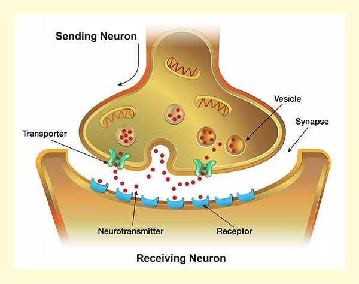

## Psychoactive Drugs: Narcotics

- **Narcotics depress central nervous system**
  - also defined as addictive
- **Addiction occurs when the molecule overstimulates the dopamine (neurotransmitter) reward pathway**
  - brain “learns” the drug as a powerful source of pleasure and reinforcement, leading to dependence
- **Active compounds are mostly alkaloids**
  - contain nitrogen, bitter, affect CNS
- **Many angiosperms families contain psychoactive alkaloids**
  - nightshade, poppy, coffee, coca, nutmeg & morning glory

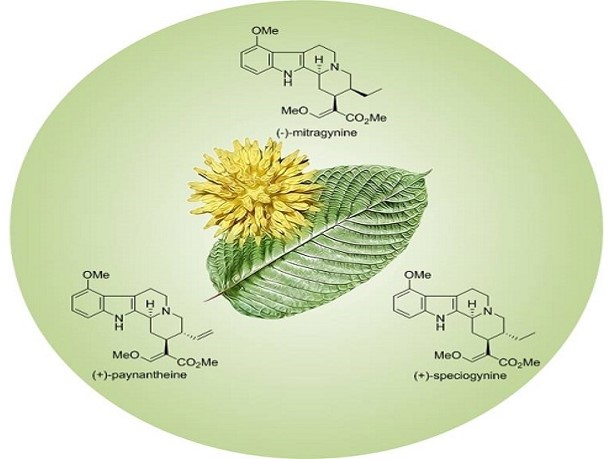

## Why Do Plants Make Mind-Altering Compounds?

- **Psychoactive compounds are secondary metabolites**
  - not for growth but costly to produce
- **Defense against herbivores & pathogens**
  - bitter, toxic alkaloids deter insects and mammals
  - nicotine, morphine, cocaine all reduce herbivory
- **Manipulating animal behavior**
  - low doses can reward (mild stimulation → animals come back)
  - can alter behaviors or memory
  - WHY? may reduce herbivore life span, promote seed dispersal or pollination
  - PA alkaloids (picture) are stored by male moths to make reproducive pheromones

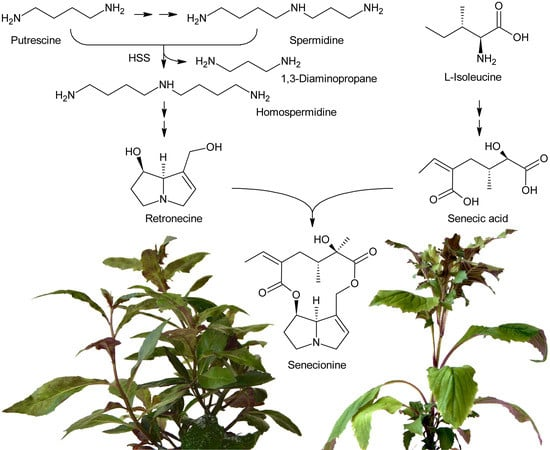

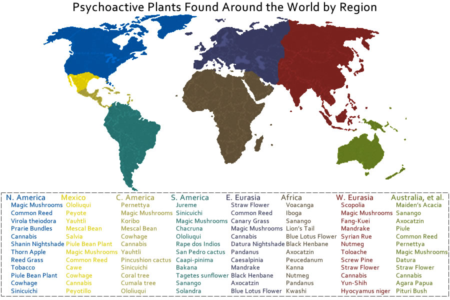

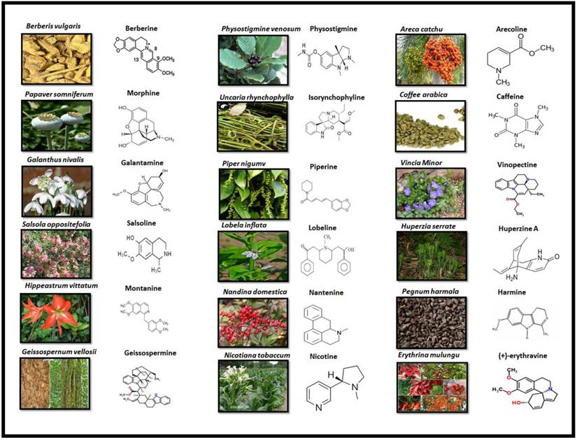

## Opium Poppy: An Ancient Curse

- **Large annual herb, ovary matures into capsule**
  - Native to Middle east
  - green capsule produces latex w/ alkaloids
  - Dried latex is crude opium
- **Opium (*Papaver somniferum*) present in early societies**
  - Babylonian and Egyptian writings
  - pain relief & inducing sleep
  - addictive properties became ‘curse’
- **Uses differ throughout history**
  - dissolved in wine
  - dissolved in alcohol (*laudanum*)
  - eaten & smoked

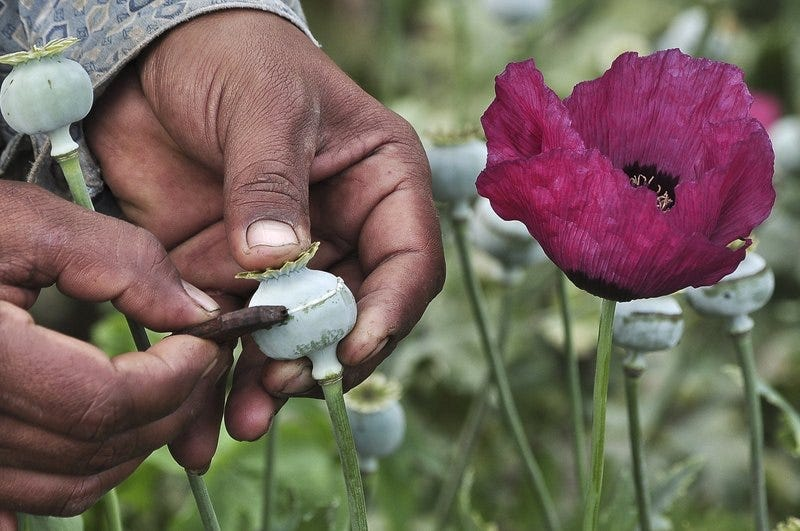

## The Lure of Laudanum

- **Marketed as a respectable household remedy—cheap, legal, and widely prescribed for pain, coughs, “nervous disorders,” women’s ailments, and even infant colic**
  - addiction could grow quietly behind a medical veneer.
- **Mix of opium, alcohol, and sweet flavor brought rapid relief and mild euphoria, making it especially alluring as a socially acceptable medicine**

[figure not shown]

[figure not shown]

## Opium Wars

- **Opium use tied to history of China**
  - use increased when tobacco was introduced (1600)
  - addiction increased, banned by Emperor
- **Addiction fueled by trade deficit with British!**
  - Chinese had no interest in European goods
  - wanted silver or Opium
- **British East India Company smuggled in opium**
  - opium widely cultivated in India
- **Chinese gov’t tried to stop smuggling**
  - 2 Opium Wars, starting in 1839
  - 25% of Chinese addicted

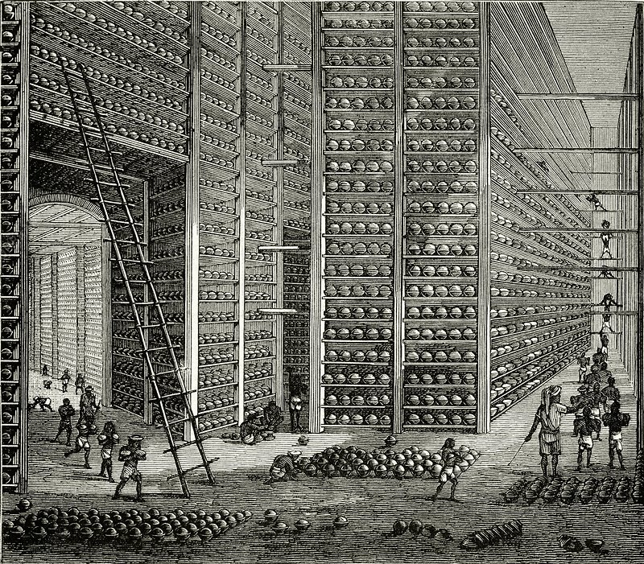

## Psychoactive Plants, Empire & Global Trade

- **Opium & colonialism: British Empire used Indian-grown opium to force open Chinese markets**
  - addiction as a tool of economic control
- **Tobacco & enslaved labor: Plantation economies in the Americas built around Nicotiana**
  - links between psychoactive demand, land use change, and slavery
- **Coca & Andean economies: Traditional coca chewing vs. global cocaine trade**
  - from sacred plant to illicit commodity
- **Psychoactive plants helped shape borders, wars, labor systems, and wealth**
  - botany” and “world history” are deeply intertwined

[figure not shown]

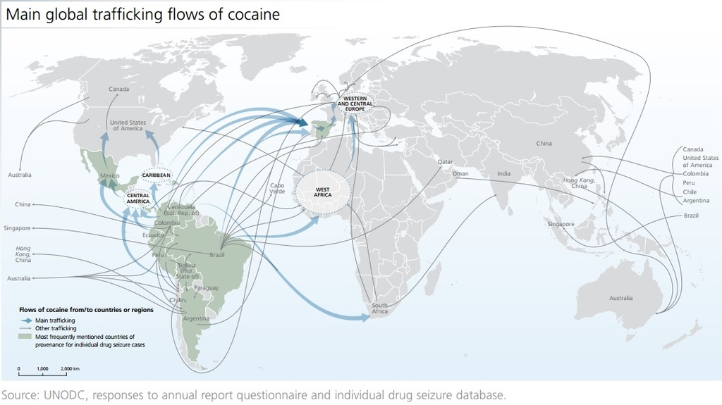

## Opium Alkaloids

- **More than 20 alkaloids identified in Opium**
- **Morphine = named after Greek god of dreams**
  - first active principle isolated
  - unsurpassed in pain relief
  - depresses areas in brain involved in pain perception
  - highly addictive
- **Codeine is one of the most commonly used opiates**
  - oral analgesic
  - 1/5 as strong as morphine
  - suppresses coughs

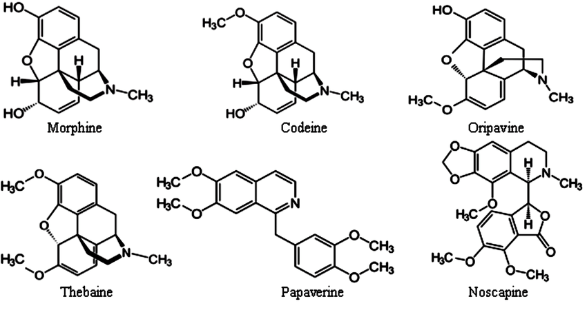

## Soldiers Disease: Did Civil War Start First Opiod Epidemic?

**Morphine, newly available from the opium poppy, was widely used to treat pain, wounds, and dysentery during the war**

[figure not shown]

[figure not shown]

## Heroin

- **In 1898, BAYER introduced heroin**
  - believed was a nonaddictive opiate
  - semi-synthetic morphine derivative
  - used widely over-the-counter
  - *Americans could order from Sears*
- **Heroin is actually 6x more addictive than morphine**
  - no longer medicinally used in USA
  - no longer legally produced in USA
- **A few European countries still allow medical-grade heroin in hospitals**
- **Illegal heroin is produced in 3 regions: the Golden Crescent (Afghanistan-Pakistan-Iran), the Golden Triangle (Myanmar-Laos-Thailand), and Mexico**

[figure not shown]

## The Origins of Cocaine

- **Cocaine is the major alkaloid of coca plant (*Erthroxylum*)**
  - small shrub with shiny leaves
  - native to Andes mountains of S.America
- **Alkaloids can be harvested from leaves 2-3 times a years**
- **Archaeology evidence indicates plants used for at least 3500 years**
  - believed a god created coca plant
- **Coca chewing was mostly restricted to ruling class**
  - soldiers and workers allowed for endurance
- **Coca leaves exchanged for food**

[figure not shown]

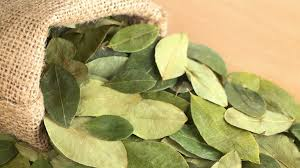

## Freud, Holmes & Coca-Cola

- **Modern history begins with isolation of cocaine in 1850’s**
  - Sigmund Freud was a huge advocate
- **Cocaine became over-the-counter drug in the USA**
  - effective in draining sinuses and curing headaches
  - Coca-wine one of the most popular beverages
- **In 1886, Atlanta pharmacist created Coca-Cola**
  - ‘brain tonic’
  - cocaine removed in 1903
- **Widespread use evident in 19th & 20th century literature**
  - Sherlock Holmes was a cocaine user

[figure not shown]

## Harrison Act (1914): First Anti-narcotic Law

**Shifted these substances from over‑the‑counter remedies to controlled drugs, setting the stage for later drug scheduling and prohibition policies**

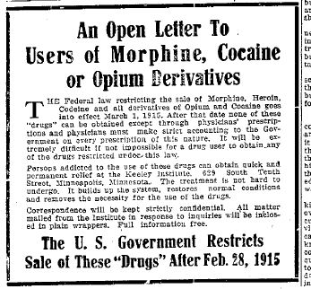

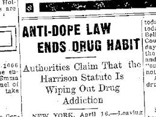

## Medical Uses of Cocaine

- **Cocaine acts as local anesthetic**
  - blocks nerves receptor at application site
- **Common synthetic local anesthics similar to cocaine**
  - Novocain, lidocaine, xylocaine
  - safer and more controllable
- **Constricts blood vessels, reducing blood flow**
  - sometimes used in ear, nose, and throat surgeries

[figure not shown]

## Tobacco: A New World Habit

- **Nicotania is a genus of 65 species**
  - annual herb w/ large leaves
  - native to Americas & Australia
  - cultivated in Andes ~5000 B.C.
- **Nicotine is major alkaloid in tobacco**
  - most addictive plant psychoactive in widespread use
- **Mayans & Aztecs used for pleasure, rituals and medicines**
  - 2 Mayan gods were depicted as habitual smokers
- **Modern cigarette appears in Europe after Crimean war**
  - first cigarette machine in 1881
  - really increased after WW1

[figure not shown]

## Nicotine Effects

- **One of the most toxic plants poisons**
  - ingestion of a few drops is lethal
  - carcinogen
- **Acts as a stimulant on the CNS in low dosages**
- **Also acts on the peripheral nervous system**
  - blocks heat, pain & hunger signals
  - increases heart rate
- **Tobacco industry now on the defensive**
  - advertising and promotion banned

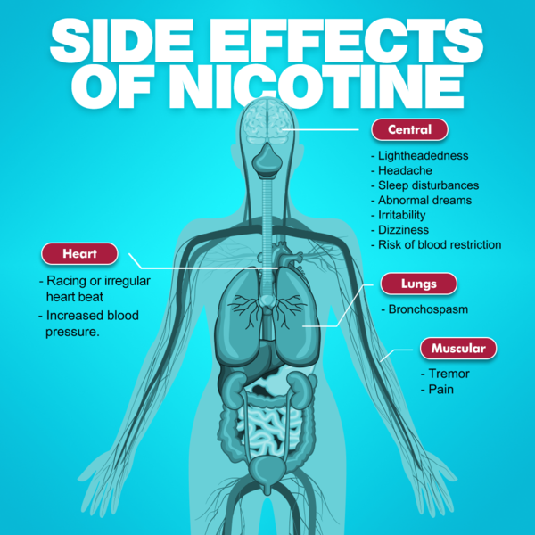

## Modern Public Health & Policy: Same Plants, New Problems

- **Opioid crisis (opium’s legacy)**
  - Morphine → heroin → modern semi-synthetic & synthetic opioids
  - plant-derived alkaloids inspired drugs now driving overdose epidemics
- **Tobacco & nicotine**
  - cigarettes and vapes deliver a plant toxin in highly engineered forms
  - huge global burden of disease (cancer, heart disease, stroke)
- **Cannabis is being re-imagined**
  - shifting laws (medical & recreational)
  - ongoing debates over benefits (pain, nausea, seizures) vs. risks (dependence, cognition, mental health)

[figure not shown]